# Part 1: EDA and Unsupervised Machine Learning

### 1.1 Give a brief overview of data, what variables are there, how are the variables scaled and variation of the data columns.

To start I import the standard packages to start

```python
import pandas as pd
import matplotlib.pyplot as plt
import seaborn as sns
import numpy as np
```

```python
# load the dataset from GitHub - original source
data = pd.read_csv("https://sds-aau.github.io/SDS-master/00_data/pokemon.csv")
```

I start with a quick view to the data frame, in order to have an idea about which are the variables involved and of which type they are

```python
data.head()
```

|  | Number | Name | Type1 | Type2 | Total | HitPoints | Attack | Defense | SpecialAttack | SpecialDefense | Speed | Generation | Legendary |
| --- | --- | --- | --- | --- | --- | --- | --- | --- | --- | --- | --- | --- | --- |
| 0 | 1 | Bulbasaur | Grass | Poison | 318 | 45 | 49 | 49 | 65 | 65 | 45 | 1 | False |
| 1 | 2 | Ivysaur | Grass | Poison | 405 | 60 | 62 | 63 | 80 | 80 | 60 | 1 | False |
| 2 | 3 | Venusaur | Grass | Poison | 525 | 80 | 82 | 83 | 100 | 100 | 80 | 1 | False |
| 3 | 3 | VenusaurMega Venusaur | Grass | Poison | 625 | 80 | 100 | 123 | 122 | 120 | 80 | 1 | False |
| 4 | 4 | Charmander | Fire | NaN | 309 | 39 | 52 | 43 | 60 | 50 | 65 | 1 | False |

We have 13 columns, the vast of majorty of which are related to the combact stats of pokemon (both individual and total), the generation to which Pokemon belongs, if they are legendary or not (bool value), their name and the PokeDex number.

It's possible to notice how the 'Mega' variations of the same Pokemon share the same number of the regular one. E.g Venusaur number is 3, as the Mega Venusaur. We have to keep this in mind if we want to use this variable for future analysis.

```python
data.shape
```

```
(800, 13)
```

I give a quick look to the presence of any null value within the data set.

```python
data.isna().any()
```

```
Number            False
Name              False
Type1             False
Type2              True
Total             False
HitPoints         False
Attack            False
Defense           False
SpecialAttack     False
SpecialDefense    False
Speed             False
Generation        False
Legendary         False
dtype: bool
```

We can see how the the only columns with null value is the 'Type2'. Having spent way too much hours on Pokemon games, I know that this is the case because not all the Pokemon have 2 types. Hence those values may be excluded from any future analysis.

```python
data.Type2.isna().sum()
```

```
386
```

Out of 800 values, 386 are null for the Type2 column. Hence, I confirm my decision of not using it for any analysis.

```python
data.describe()
```

|  | Number | Total | HitPoints | Attack | Defense | SpecialAttack | SpecialDefense | Speed | Generation |
| --- | --- | --- | --- | --- | --- | --- | --- | --- | --- |
| count | 800.000000 | 800.00000 | 800.000000 | 800.000000 | 800.000000 | 800.000000 | 800.000000 | 800.000000 | 800.00000 |
| mean | 362.813750 | 435.10250 | 69.258750 | 79.001250 | 73.842500 | 72.820000 | 71.902500 | 68.277500 | 3.32375 |
| std | 208.343798 | 119.96304 | 25.534669 | 32.457366 | 31.183501 | 32.722294 | 27.828916 | 29.060474 | 1.66129 |
| min | 1.000000 | 180.00000 | 1.000000 | 5.000000 | 5.000000 | 10.000000 | 20.000000 | 5.000000 | 1.00000 |
| 25% | 184.750000 | 330.00000 | 50.000000 | 55.000000 | 50.000000 | 49.750000 | 50.000000 | 45.000000 | 2.00000 |
| 50% | 364.500000 | 450.00000 | 65.000000 | 75.000000 | 70.000000 | 65.000000 | 70.000000 | 65.000000 | 3.00000 |
| 75% | 539.250000 | 515.00000 | 80.000000 | 100.000000 | 90.000000 | 95.000000 | 90.000000 | 90.000000 | 5.00000 |
| max | 721.000000 | 780.00000 | 255.000000 | 190.000000 | 230.000000 | 194.000000 | 230.000000 | 180.000000 | 6.00000 |

In the perspective of the PCA analysis I will perform afterwards, I look at the different numeric variables. The different combact stats (HitPoints, Attack, Defense, SpecialAtaack, SpecialDefense and Speed) are on the same scale. However, the variables 'Number', 'Total' and 'Generation' are different since they describe different values. So scaling will be required afterwards.

Now I will give a quick look to the dataset visually

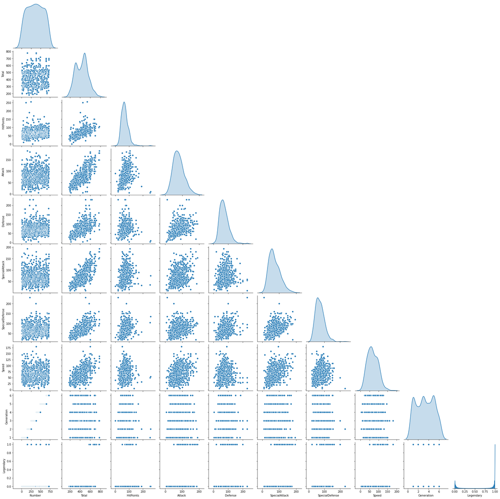

```python
sns.pairplot(data, corner=True, diag_kind='kde')
```

We can see thet that the 'Legendary' and the 'Generation' variables can be consider as categorical variables, since they clearly divide the data set in different categories.

Being the 'total' variable the sum of the others combact stats (HitPoints, Attack, Defense, SpecialAttack, SpecialDefense, Speed) it's noticeable (and predictable) that to higher values of the total correspond higher values of the single stats. As a matter of fact all the scatter plots that show this relationship have a behaviour which can be almost defined as linear.

It's also possilbe to notice tha attack and defense seem to have a relantionship tending to a lienear behaviour as well. Which is interesting since in some other games the player has to trade between attack or defense. This doesn't seem to be the case in Pokemon. It may be deducted that attack and defense develop evenly when pokemon evolve, so the simil linear behaviour of this relantionship may be caused by the lower level pokemon being in the bottom left and the strongest one in the top right.

### 1.2 Execute a PCA analysis on all numerical variables in the dataset. Hint: Don't forget to scale them first. Use 4 components. What is the individuel and cumulative explained variance?

The first step required before performing a PCA analysis is to scale the valued of the data frame. So I import StandardScaler.

```python
from sklearn.preprocessing import StandardScaler
```

I now scale the numerical variables in which I'm interested in. I will excluede the 'Generation' variable because, although it is numerical, it acts more like a label rather than a numerical variable that effects the statistics of the Pokemon.

```python
scaled_data = StandardScaler().fit_transform(data.loc[:,'Total':'Speed'])
```

I create a new dataframe from the previously sclaed numpy array. This is just a 'safe' creation so that I can use relplot afterwards if I need it

```python
scaled_data_df=pd.DataFrame(scaled_data)
scaled_data_df.describe()
```

|  | 0 | 1 | 2 | 3 | 4 | 5 | 6 |
| --- | --- | --- | --- | --- | --- | --- | --- |
| count | 8.000000e+02 | 8.000000e+02 | 8.000000e+02 | 8.000000e+02 | 8.000000e+02 | 8.000000e+02 | 8.000000e+02 |
| mean | -7.993606e-17 | -2.660372e-16 | -1.355860e-16 | 2.498002e-17 | 2.120526e-16 | -1.171285e-16 | -7.842685e-17 |
| std | 1.000626e+00 | 1.000626e+00 | 1.000626e+00 | 1.000626e+00 | 1.000626e+00 | 1.000626e+00 | 1.000626e+00 |
| min | -2.127839e+00 | -2.674852e+00 | -2.281379e+00 | -2.209039e+00 | -1.920993e+00 | -1.866223e+00 | -2.178804e+00 |
| 25% | -8.766721e-01 | -7.546915e-01 | -7.399327e-01 | -7.650653e-01 | -7.054650e-01 | -7.875334e-01 | -8.015032e-01 |
| 50% | 1.242618e-01 | -1.668874e-01 | -1.233542e-01 | -1.232993e-01 | -2.391303e-01 | -6.840691e-02 | -1.128526e-01 |
| 75% | 6.664343e-01 | 4.209167e-01 | 6.473688e-01 | 5.184667e-01 | 6.782494e-01 | 6.507196e-01 | 7.479606e-01 |
| max | 2.876830e+00 | 7.278632e+00 | 3.421972e+00 | 5.010829e+00 | 3.705602e+00 | 5.684605e+00 | 3.846888e+00 |

StandardScaler allowed us to obtain a new data frame where the mean is very colose to 0 (all the value have either -16 or -17 exponent) and standard deviation extremely close to 1. So the numerical variables are now scaled. Let's import PCA and initialize it with a number of components equal to 4

```python
from sklearn.decomposition import PCA
pca = PCA(n_components=4)
```

Now I transform the data and assing it to the variable 'pca_data'

```python
pca_data = pca.fit_transform(scaled_data_df)
```

```python
pca_data
```

```
array([[-1.84008756, -0.0254935 ,  0.66510726,  0.16998025],
       [-0.44354259, -0.05076025,  0.66875184,  0.26430772],
       [ 1.48030857, -0.05842799,  0.62757409,  0.33938684],
       ...,
       [ 2.8062946 , -0.50687719,  1.1187995 ,  0.83837887],
       [ 4.07411541, -0.93954987,  0.4159322 ,  0.21407913],
       [ 2.62404137,  0.54375306,  0.24505892, -0.3299462 ]])
```

I also create a data frame from the numpy array in case I'll need it aftewrwards

```python
pca_data_df = pd.DataFrame(pca_data, columns= ['principal component 1', 'principal component 2','principal component 3','principal component 4'])
```

```python
pca_data.shape
```

```
(800, 4)
```

So we can see that the newly created nparray frame has 800 rows and 4 columns as intended by our choice of setting the pca's number of attributes to 4. Now let's calculate the individual explainexd variance for each of the 4 components

```python
print(pca.explained_variance_ratio_)
```

```
[0.5299246  0.15623011 0.11125624 0.10315768]
```

```python
#The cumulative explained variance can be found in this way
print(pca.explained_variance_ratio_.cumsum())
```

```
[0.5299246  0.68615471 0.79741095 0.90056862]
```

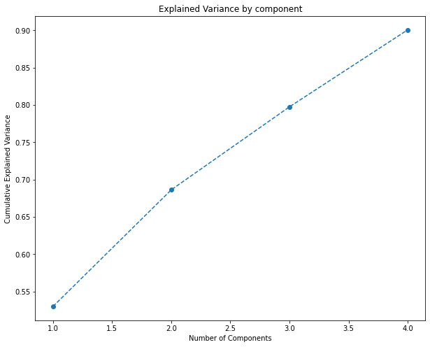

```python
plt.figure(figsize=(10,8))
plt.plot( range(1,5), pca.explained_variance_ratio_.cumsum(), marker= 'o', linestyle = '--')
plt.title('Explained Variance by component')
plt.xlabel('Number of Components')
plt.ylabel('Cumulative Explained Variance')
```

From the explained variance values we can see how the Principal component accounts for 53% of the data. The second bigger component holds 15.6% of the data. The 4 compenents together hold 90% of the information. Since the rule of thumb is to preserve around 80% of the variance, we can say that reduced number of data with 4 components is a good choice.

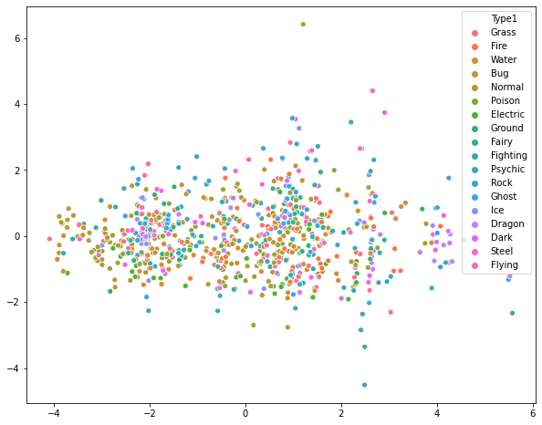

```python
plt.figure(figsize=(10,8))
sns.scatterplot(x=pca_data[:,0], y=pca_data[:,1], hue = data['Type1'])
```

How of curiosity I do a quick plot to see if after the reduction the data can be used to identify the different Type1 of Pokemon. This is not the case. I try with UMAP to see if I can find a better result

### 1.3 Use a different dimensionality reduction method (eg. UMAP/NMF) – do the findings differ?

```python
import umap
reducer = umap.UMAP(n_components=4)
```

After importing umap and set the reducer, I reduced the scaled data as we did for pca

```python
umap_data = reducer.fit_transform(scaled_data_df)
umap_data.shape
```

```
(800, 4)
```

Again, we obtain the intended result, the columns have been reduced to 4

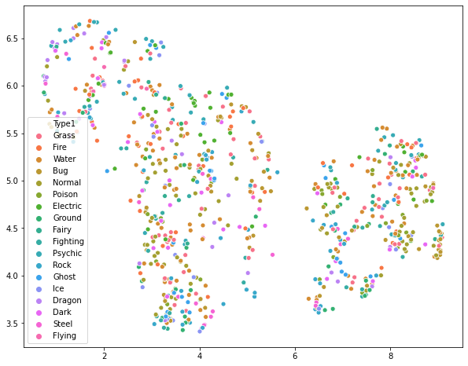

```python
plt.figure(figsize=(10,8))
sns.scatterplot(x=umap_data[:,0], y=umap_data[:,1],  hue = data['Type1'])
```

I plot also with relplot to have a better view of the top left corner

```python
umap_data_df = pd.DataFrame(umap_data, columns= ['principal component 1', 'principal component 2','principal component 3','principal component 4'])
```

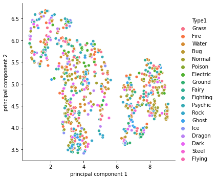

```python
plt.figure(figsize=(10,8))
sns.relplot(x='principal component 1', y='principal component 2', data = umap_data_df, kind= 'scatter', hue = data['Type1'])
```

From this 2 scattern plot we can see that the result of the 2 different algoritsm for dimensionality reduction is quite different. Both algoritms weren't able to clearly define all the different type of Pokèmon. To be fair, this wasn't expected since the numerical variables used for the algorithms are not really exclusive of any Type of Pokemon.

### 1.4 Perform a cluster analysis (KMeans) on all numerical variables (scaled & before PCA). Pick a realistic number of clusters (up to you where the large clusters remain mostly stable).

```python
from sklearn.cluster import KMeans
```

In order to decide which claster is better, I use the elbow method

```python
wcss = []
for i in range(1,21):
  kmeans_sc = KMeans(n_clusters = i, init = 'k-means++')
  kmeans_sc.fit(scaled_data)
  wcss.append(kmeans_sc.inertia_)
```

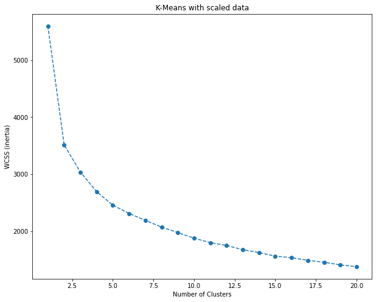

```python
plt.figure(figsize=(10,8))
plt.plot( range(1,21), wcss, marker= 'o', linestyle = '--')
plt.title('K-Means with scaled data')
plt.xlabel('Number of Clusters')
plt.ylabel('WCSS (inertia)')
```

From this graph, it's possible to determine the optimal number of clusters. According to the Elbow-method I see that the part of the the WCSS graph that is steeply declining (the elbow) is mostly between the first and second cluster marks. There is a lower, but still noticeable, decline between the second and the third. So I decide to take 3 clusters.

```python
clusterer = KMeans(n_clusters=3)
data_scaled_kmeans = clusterer.fit(scaled_data)
print(data_scaled_kmeans.inertia_)
```

```
3037.12883190608
```

### 1.5 Visualize the first 2 principal components and color the datapoints by cluster.

To proceed, I'll create a new data frame to have both the principal components values and the initial data in one data frame. The step is not required, I did it for trainining.

```python
data_scaled_KDMmeans = pd.concat([data, pca_data_df ], axis=1 )
data_scaled_KDMmeans['Segment K-means Scaled Data'] = data_scaled_kmeans.labels_
data_scaled_KDMmeans.head()
```

|  | Number | Name | Type1 | Type2 | Total | HitPoints | Attack | Defense | SpecialAttack | SpecialDefense | Speed | Generation | Legendary | principal component 1 | principal component 2 | principal component 3 | principal component 4 | Segment K-means Scaled Data |
| --- | --- | --- | --- | --- | --- | --- | --- | --- | --- | --- | --- | --- | --- | --- | --- | --- | --- | --- |
| 0 | 1 | Bulbasaur | Grass | Poison | 318 | 45 | 49 | 49 | 65 | 65 | 45 | 1 | False | -1.840088 | -0.025494 | 0.665107 | 0.169980 | 1 |
| 1 | 2 | Ivysaur | Grass | Poison | 405 | 60 | 62 | 63 | 80 | 80 | 60 | 1 | False | -0.443543 | -0.050760 | 0.668752 | 0.264308 | 0 |
| 2 | 3 | Venusaur | Grass | Poison | 525 | 80 | 82 | 83 | 100 | 100 | 80 | 1 | False | 1.480309 | -0.058428 | 0.627574 | 0.339387 | 0 |
| 3 | 3 | VenusaurMega Venusaur | Grass | Poison | 625 | 80 | 100 | 123 | 122 | 120 | 80 | 1 | False | 3.060557 | 0.711939 | 0.998631 | -0.183487 | 2 |
| 4 | 4 | Charmander | Fire | NaN | 309 | 39 | 52 | 43 | 60 | 50 | 65 | 1 | False | -2.045946 | -0.711499 | 0.407573 | -0.283886 | 1 |

From this data frame I take all the info that I need to plot the principal components 1 and 2. I could have also used the data_pca with iloc[:,0] and [:,1]

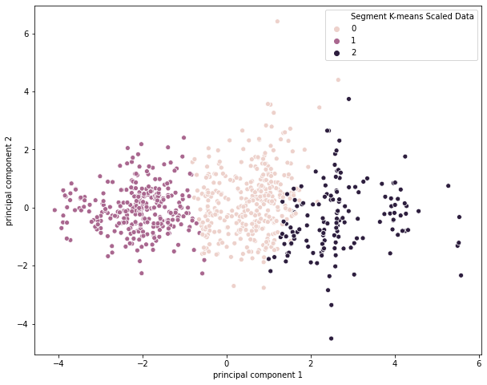

```python
x_axis= data_scaled_KDMmeans['principal component 1'] # it corrsponds to pca_data[:,0]
y_axis= data_scaled_KDMmeans['principal component 2'] #it correspond to pca_data[:,1]
plt.figure(figsize=(10,8))
sns.scatterplot(x_axis,y_axis, hue = data_scaled_KDMmeans['Segment K-means Scaled Data'])
```

We obtained a cluster plot of the analysis conducted on all the scaled numerical variables before transforming them with PCA. We can see from the scatterplot that the cluster analysis is able to divide the Pokemon

### 1.6 Inspect the distribution of the variable “Type1” across clusters. Does the algorithm separate the different types of pokemon?

```python
pd.crosstab(data_scaled_kmeans.labels_, data['Type1'])
```

| Type1 row_0 | Bug | Dark | Dragon | Electric | Fairy | Fighting | Fire | Flying | Ghost | Grass | Ground | Ice | Normal | Poison | Psychic | Rock | Steel | Water |
| --- | --- | --- | --- | --- | --- | --- | --- | --- | --- | --- | --- | --- | --- | --- | --- | --- | --- | --- |
| 0 | 32 | 15 | 8 | 17 | 5 | 16 | 19 | 0 | 13 | 36 | 15 | 11 | 47 | 14 | 16 | 22 | 13 | 53 |
| 1 | 32 | 10 | 5 | 13 | 8 | 9 | 15 | 1 | 13 | 26 | 13 | 8 | 42 | 14 | 18 | 15 | 6 | 43 |
| 2 | 5 | 6 | 19 | 14 | 4 | 2 | 18 | 3 | 6 | 8 | 4 | 5 | 9 | 0 | 23 | 7 | 8 | 16 |

With a cross tab we can check if the cluster algorithm is able to separate the different kind of Pokèmon. As we can see the algorithm can separate some kind of Pokèmon from different categories. However, none of the Types is defined with perfect accuracy. I am curious to see if Increasing the number of clusters to match the number of Types could help better defining pokemon types.

```python
clusterer = KMeans(n_clusters=18)
data_scaled_kmeans = clusterer.fit(scaled_data)
```

```python
data_scaled_KDMmeans = pd.concat([data, pca_data_df ], axis=1 )
data_scaled_KDMmeans['Segment K-means Scaled Data'] = data_scaled_kmeans.labels_
```

```python
pd.crosstab(data_scaled_kmeans.labels_, data['Type1'])
```

| Type1 row_0 | Bug | Dark | Dragon | Electric | Fairy | Fighting | Fire | Flying | Ghost | Grass | Ground | Ice | Normal | Poison | Psychic | Rock | Steel | Water |
| --- | --- | --- | --- | --- | --- | --- | --- | --- | --- | --- | --- | --- | --- | --- | --- | --- | --- | --- |
| 0 | 0 | 2 | 0 | 1 | 3 | 1 | 1 | 0 | 0 | 4 | 1 | 2 | 6 | 2 | 3 | 2 | 0 | 12 |
| 1 | 2 | 0 | 1 | 2 | 6 | 0 | 0 | 0 | 3 | 8 | 1 | 1 | 3 | 0 | 10 | 1 | 1 | 11 |
| 2 | 8 | 2 | 1 | 1 | 0 | 7 | 3 | 0 | 1 | 1 | 4 | 0 | 20 | 3 | 0 | 3 | 1 | 3 |
| 3 | 3 | 5 | 1 | 6 | 0 | 2 | 9 | 3 | 2 | 5 | 0 | 1 | 2 | 0 | 8 | 1 | 0 | 6 |
| 4 | 7 | 1 | 0 | 11 | 0 | 1 | 5 | 0 | 3 | 7 | 0 | 4 | 4 | 1 | 9 | 1 | 0 | 7 |
| 5 | 3 | 1 | 8 | 1 | 0 | 0 | 5 | 0 | 1 | 4 | 3 | 1 | 4 | 0 | 9 | 3 | 4 | 5 |
| 6 | 1 | 1 | 0 | 0 | 0 | 0 | 0 | 0 | 3 | 1 | 0 | 1 | 0 | 0 | 1 | 4 | 2 | 0 |
| 7 | 8 | 0 | 1 | 0 | 0 | 0 | 1 | 0 | 1 | 4 | 4 | 1 | 0 | 2 | 0 | 12 | 5 | 4 |
| 8 | 5 | 3 | 0 | 8 | 0 | 3 | 6 | 1 | 1 | 6 | 2 | 2 | 14 | 4 | 4 | 0 | 0 | 15 |
| 9 | 4 | 4 | 4 | 2 | 1 | 3 | 4 | 0 | 6 | 7 | 4 | 3 | 4 | 5 | 1 | 2 | 1 | 8 |
| 10 | 1 | 4 | 1 | 3 | 2 | 3 | 6 | 0 | 3 | 9 | 3 | 3 | 5 | 6 | 1 | 2 | 1 | 10 |
| 11 | 0 | 0 | 0 | 0 | 0 | 0 | 0 | 0 | 0 | 0 | 0 | 0 | 2 | 0 | 0 | 0 | 0 | 0 |
| 12 | 3 | 1 | 2 | 7 | 3 | 1 | 1 | 0 | 2 | 4 | 1 | 2 | 2 | 1 | 3 | 1 | 3 | 10 |
| 13 | 8 | 5 | 3 | 2 | 0 | 3 | 8 | 0 | 1 | 5 | 3 | 1 | 17 | 3 | 1 | 6 | 0 | 7 |
| 14 | 4 | 0 | 0 | 0 | 0 | 0 | 1 | 0 | 3 | 3 | 5 | 1 | 0 | 1 | 0 | 5 | 8 | 5 |
| 15 | 0 | 1 | 10 | 0 | 1 | 0 | 1 | 0 | 1 | 0 | 1 | 0 | 2 | 0 | 4 | 1 | 1 | 3 |
| 16 | 0 | 0 | 0 | 0 | 0 | 1 | 0 | 0 | 1 | 0 | 0 | 0 | 3 | 0 | 1 | 0 | 0 | 3 |
| 17 | 12 | 1 | 0 | 0 | 1 | 2 | 1 | 0 | 0 | 2 | 0 | 1 | 10 | 0 | 2 | 0 | 0 | 3 |

Even with a higher number of clusters, the algorithm is not able to define the diffent kind of Pokemon. We can assume that the attack points and stats are not a variable good enough to determine the Type of Pokemon.

### 1.7 Perform a cluster analysis on all numerical variables scaled and AFTER dimensionality reduction and visualize the first 2 principal components.

I know perfrom the same analysis with the data_pca instead of the merely scaled data. I take once again a number of clusters equal to 3.

```python
clusterer2 = KMeans(n_clusters=3)
data_pca_kmeans = clusterer2.fit(pca_data)
```

```python
data_pca_KMmeans = pd.concat([data, pca_data_df ], axis=1 )
data_pca_KMmeans['Segment K-means Scaled Data'] = data_pca_kmeans.labels_
```

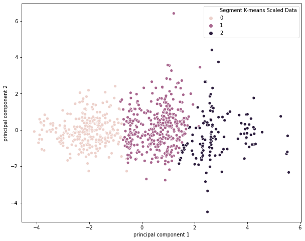

```python
x_axis= data_pca_KMmeans['principal component 1']
y_axis= data_pca_KMmeans['principal component 2']
plt.figure(figsize=(10,8))
sns.scatterplot(x_axis,y_axis, hue = data_pca_KMmeans['Segment K-means Scaled Data'])
```

We can see that the scatter plot obtained using the numerical values after PCA is pretty much identical to the one obtained using the merely numerical values.

### 1.8 Again, inspect the distribution of the variable “Type 1” across clusters, does it differ from the distribution before dimensionality reduction?

```python
pd.crosstab(data_pca_kmeans.labels_, data['Type1'])
```

| Type1 row_0 | Bug | Dark | Dragon | Electric | Fairy | Fighting | Fire | Flying | Ghost | Grass | Ground | Ice | Normal | Poison | Psychic | Rock | Steel | Water |
| --- | --- | --- | --- | --- | --- | --- | --- | --- | --- | --- | --- | --- | --- | --- | --- | --- | --- | --- |
| 0 | 32 | 10 | 5 | 13 | 8 | 9 | 15 | 1 | 12 | 25 | 14 | 8 | 42 | 14 | 18 | 15 | 6 | 43 |
| 1 | 32 | 16 | 8 | 23 | 6 | 17 | 22 | 0 | 16 | 38 | 14 | 13 | 47 | 13 | 18 | 22 | 13 | 55 |
| 2 | 5 | 5 | 19 | 8 | 3 | 1 | 15 | 3 | 4 | 7 | 4 | 3 | 9 | 1 | 21 | 7 | 8 | 14 |

Despite the cluster plot seems visualy identical to the previous scatter plot, from the crosstab we can actually see ho the values bettwen the 2 cluster analysis are not identical, just very similar. Nonetheless, none of the 2 results helps us to define the Type of Pokemon. Which is fair since,as we saw before, the numerical values are not exclusive of only one kind of Pokemon apparently.

# Part 2: Supervised ML

### 2.1 Perform necessary ML preprocessing of your data if deemed necessary.

```python
data.Legendary.value_counts()
```

```
False    735
True      65
Name: Legendary, dtype: int64
```

There seem to be enough legendary Pokemon to train the algorithm to recognize them. Before doing so I want to slightly modify the data set. More specifically, I will assing dummies to the 'Generation' and to the 'Type1' variables to make them numerical variables (Generation technically is numerical, but is more like a class as it is). Also, I will drop the variables 'Number', 'Name' (since I don't believe they are relevant for determinig if a Pokemon is legendary or not) and 'Type2' which has a lot of null values.

```python
data_sml = data
data_sml.head()
```

|  | Number | Name | Type1 | Type2 | Total | HitPoints | Attack | Defense | SpecialAttack | SpecialDefense | Speed | Generation | Legendary |
| --- | --- | --- | --- | --- | --- | --- | --- | --- | --- | --- | --- | --- | --- |
| 0 | 1 | Bulbasaur | Grass | Poison | 318 | 45 | 49 | 49 | 65 | 65 | 45 | 1 | False |
| 1 | 2 | Ivysaur | Grass | Poison | 405 | 60 | 62 | 63 | 80 | 80 | 60 | 1 | False |
| 2 | 3 | Venusaur | Grass | Poison | 525 | 80 | 82 | 83 | 100 | 100 | 80 | 1 | False |
| 3 | 3 | VenusaurMega Venusaur | Grass | Poison | 625 | 80 | 100 | 123 | 122 | 120 | 80 | 1 | False |
| 4 | 4 | Charmander | Fire | NaN | 309 | 39 | 52 | 43 | 60 | 50 | 65 | 1 | False |

Since the Type of Pokemon is a string variable, but may be relevant to determine trends in the legendary Pokemon definition, I set dummies to replace the string values in the data frame

```python
data_sml = pd.get_dummies(data_sml, columns=(['Type1']))
data_sml.drop(['Number','Name','Type2'], axis=1, inplace=True)
```

```python
data_sml.head()
```

|  | Total | HitPoints | Attack | Defense | SpecialAttack | SpecialDefense | Speed | Generation | Legendary | Type1_Bug | Type1_Dark | Type1_Dragon | Type1_Electric | Type1_Fairy | Type1_Fighting | Type1_Fire | Type1_Flying | Type1_Ghost | Type1_Grass | Type1_Ground | Type1_Ice | Type1_Normal | Type1_Poison | Type1_Psychic | Type1_Rock | Type1_Steel | Type1_Water |
| --- | --- | --- | --- | --- | --- | --- | --- | --- | --- | --- | --- | --- | --- | --- | --- | --- | --- | --- | --- | --- | --- | --- | --- | --- | --- | --- | --- |
| 0 | 318 | 45 | 49 | 49 | 65 | 65 | 45 | 1 | False | 0 | 0 | 0 | 0 | 0 | 0 | 0 | 0 | 0 | 1 | 0 | 0 | 0 | 0 | 0 | 0 | 0 | 0 |
| 1 | 405 | 60 | 62 | 63 | 80 | 80 | 60 | 1 | False | 0 | 0 | 0 | 0 | 0 | 0 | 0 | 0 | 0 | 1 | 0 | 0 | 0 | 0 | 0 | 0 | 0 | 0 |
| 2 | 525 | 80 | 82 | 83 | 100 | 100 | 80 | 1 | False | 0 | 0 | 0 | 0 | 0 | 0 | 0 | 0 | 0 | 1 | 0 | 0 | 0 | 0 | 0 | 0 | 0 | 0 |
| 3 | 625 | 80 | 100 | 123 | 122 | 120 | 80 | 1 | False | 0 | 0 | 0 | 0 | 0 | 0 | 0 | 0 | 0 | 1 | 0 | 0 | 0 | 0 | 0 | 0 | 0 | 0 |
| 4 | 309 | 39 | 52 | 43 | 60 | 50 | 65 | 1 | False | 0 | 0 | 0 | 0 | 0 | 0 | 1 | 0 | 0 | 0 | 0 | 0 | 0 | 0 | 0 | 0 | 0 | 0 |

```python
data_sml_df = pd.DataFrame(data_sml)
```

Now I scale the data once again

```python
scaled_data_sml = StandardScaler().fit_transform(data_sml)
scaled_data_sml.shape
```

```
(800, 27)
```

## 2.2 Split the data in a training (75%) and test (25%) dataset

The splitting choice defined by the assignment is to take 75% of your original data set as the training set, while the 25% that remains will compose the test set. When importing train_test_split from sklearn, those are the default values. So nothing requires explicitily setting.

```python
from sklearn.model_selection import train_test_split
```

```python
X = scaled_data_sml
```

I transform the 'Legendary' values in labels. This step may be redundand due to the fact that being legendary bool values they could also be translated by the compiler to 0s and 1s

```python
from sklearn.preprocessing import LabelEncoder
y = data_sml.loc[:,'Legendary']
labelencoder_y = LabelEncoder()
y = labelencoder_y.fit_transform(y)
```

```python
X_train, X_test, y_train, y_test = train_test_split(X, y , random_state = 18)
```

### 2.3 Define a n-fold cross-validation workflow for your model testing

```python
from sklearn.model_selection import cross_val_score
from sklearn.linear_model import LogisticRegression
from sklearn.ensemble import RandomForestRegressor
from sklearn.neighbors import KNeighborsClassifier
from xgboost import XGBRegressor
```

```python
model_lrs = LogisticRegression()
model_rf = RandomForestRegressor()
model_knn = KNeighborsClassifier(n_neighbors=6)
model_xgb = XGBRegressor()
```

```python
cv_lrs_results = cross_val_score(model_lrs, X, y, cv=5)
print(cv_lrs_results)
cv_rf_results = cross_val_score(model_rf, X, y, cv=5)
print(cv_rf_results)
cv_knn_results = cross_val_score(model_knn, X, y, cv=5)
print(cv_knn_results)
cv_xgb_results = cross_val_score(model_xgb, X, y, cv=5)
print(cv_xgb_results)
```

```
[1. 1. 1. 1. 1.]
[1. 1. 1. 1. 1.]
[0.94375 0.9625  0.95625 0.95    0.9625 ]
[19:37:59] WARNING: /workspace/src/objective/regression_obj.cu:152: reg:linear is now deprecated in favor of reg:squarederror.
[19:37:59] WARNING: /workspace/src/objective/regression_obj.cu:152: reg:linear is now deprecated in favor of reg:squarederror.
[19:37:59] WARNING: /workspace/src/objective/regression_obj.cu:152: reg:linear is now deprecated in favor of reg:squarederror.
[19:37:59] WARNING: /workspace/src/objective/regression_obj.cu:152: reg:linear is now deprecated in favor of reg:squarederror.
[19:37:59] WARNING: /workspace/src/objective/regression_obj.cu:152: reg:linear is now deprecated in favor of reg:squarederror.
[0.99999996 0.99999998 0.99999998 0.99999998 0.99999998]
```

```python
print(np.mean(cv_lrs_results))
print(np.mean(cv_rf_results))
print(np.mean(cv_knn_results))
print(np.mean(cv_xgb_results))
```

```
1.0
1.0
0.9550000000000001
0.9999999751189537
```

### 2.4 Fit three separate models on your training data, where you predict the “legendary” variable. Use a 1. Logistic regression, 2. Decision tree, and 3. KNeighborsClassifier.

I now fit the data one the 4 different models.

```python
model_lrs.fit(X_train, y_train)
```

```
LogisticRegression(C=1.0, class_weight=None, dual=False, fit_intercept=True,
                   intercept_scaling=1, l1_ratio=None, max_iter=100,
                   multi_class='auto', n_jobs=None, penalty='l2',
                   random_state=None, solver='lbfgs', tol=0.0001, verbose=0,
                   warm_start=False)
```

```python
model_rf.fit(X_train, y_train)
```

```
RandomForestRegressor(bootstrap=True, ccp_alpha=0.0, criterion='mse',
                      max_depth=None, max_features='auto', max_leaf_nodes=None,
                      max_samples=None, min_impurity_decrease=0.0,
                      min_impurity_split=None, min_samples_leaf=1,
                      min_samples_split=2, min_weight_fraction_leaf=0.0,
                      n_estimators=100, n_jobs=None, oob_score=False,
                      random_state=None, verbose=0, warm_start=False)
```

```python
model_knn.fit(X_train, y_train)
```

```
KNeighborsClassifier(algorithm='auto', leaf_size=30, metric='minkowski',
                     metric_params=None, n_jobs=None, n_neighbors=6, p=2,
                     weights='uniform')
```

```python
model_xgb.fit(X_train, y_train)
```

```
[19:37:59] WARNING: /workspace/src/objective/regression_obj.cu:152: reg:linear is now deprecated in favor of reg:squarederror.
```

```
XGBRegressor(base_score=0.5, booster='gbtree', colsample_bylevel=1,
             colsample_bynode=1, colsample_bytree=1, gamma=0,
             importance_type='gain', learning_rate=0.1, max_delta_step=0,
             max_depth=3, min_child_weight=1, missing=None, n_estimators=100,
             n_jobs=1, nthread=None, objective='reg:linear', random_state=0,
             reg_alpha=0, reg_lambda=1, scale_pos_weight=1, seed=None,
             silent=None, subsample=1, verbosity=1)
```

We now look at the scores of the fitted models

```python
model_lrs.score(X_test,y_test)
```

```
1.0
```

```python
model_rf.score(X_test,y_test)
```

```
1.0
```

```python
model_knn.score(X_test,y_test)
```

```
0.965
```

```python
model_xgb.score(X_test,y_test)
```

```
0.9999999768863215
```

We obtain quite high results. With 3 models able to identify for sure which pokemon are legendary. The K Neighbors Classifier registers a very good 96,5% as well. Let's see now how the model can predict legendary pokemon

### 2.5 Use the fitted models to predict the “legendary” variable in your test data.

Now I will simply predict the number of Pokemon for each one of the different models. Since at the beggining we had a number of legendary Pokemon = 65 with the amount of data we considered for test (25%) we should have around 15 legendary pokemon (note, this is only an educated guess so far since we don't know the precise number yet)

I will start with the Logistic Regression model's predictions

```python
y_pred_lrs = model_lrs.predict(X_test)
print (y_pred_lrs.sum())
```

```
14
```

We continue with the Random Forest Regressor's predictions

```python
y_pred_rf = model_rf.predict(X_test)
print (y_pred_rf.sum())
```

```
14.0
```

Now is the turn of the K Neighbors Classifier's predictions

```python
y_pred_knn = model_knn.predict(X_test)
print (y_pred_knn.sum())
```

```
7
```

And, to finish, we have the XGB Regressor's ones

```python
y_pred_xgb = model_xgb.predict(X_test)
print (y_pred_xgb.sum())
```

```
14.002633
```

### 2.6 Evaluate the performance of these 3 models by comparing the predicted and the true values of “legendary” in the test data. To do so, also create a confusion matrix, provide and discuss further useful metrics of model performance.

I will start this part by obtaining the initial lebels of legendary pokemon and see how well it performed for each model. After I also do a cross tab between the predicted and true values in order to numerically visualize the accuracy of the models.

```python
true_leg_lrs = labelencoder_y.inverse_transform(y_test)
predicted_leg_lrs = labelencoder_y.inverse_transform(model_lrs.predict(X_test))
```

Instead of the confusion matrix I use cross plot with both the true results and the test result. This achieves the same as the confusion matrix

```python
df = pd.DataFrame({'true_leg': true_leg_lrs, 'predicted_leg': predicted_leg_lrs})

pd.crosstab(df.true_leg, df.predicted_leg)
```

| predicted_leg true_leg | False | True |
| --- | --- | --- |
| False | 186 | 0 |
| True | 0 | 14 |

As we saw from the scores, the Logistic Regression is able to correclty predict if a pokemon is legendary or not. We also see that the toal number of Pokemon in this case is 200 (25% of 800)

```python
true_leg_knn = labelencoder_y.inverse_transform(y_test)
predicted_leg_knn = labelencoder_y.inverse_transform(model_knn.predict(X_test))
```

```python
df = pd.DataFrame({'true_leg': true_leg_knn, 'predicted_leg': predicted_leg_knn})

pd.crosstab(df.true_leg, df.predicted_leg)
```

| predicted_leg true_leg | False | True |
| --- | --- | --- |
| False | 186 | 0 |
| True | 7 | 7 |

The KNeighborsClassifier cannot predict with abolsute precision if a Pokemon will be legendary or not. By looking at the results of the previous model, we know that the 'False', or 'Not Legendary' prediction is accurate, while the model is not able to correclty clasify 50% of the Legendary Pokemon, that should be 14 in total.

```python
true_leg_rf = labelencoder_y.inverse_transform(y_test)
predicted_leg_rf = (model_rf.predict(X_test))
```

```python
df = pd.DataFrame({'true_leg': true_leg_rf, 'predicted_leg': predicted_leg_rf})

pd.crosstab(df.true_leg, df.predicted_leg)
```

| predicted_leg true_leg | 0.0 | 1.0 |
| --- | --- | --- |
| False | 186 | 0 |
| True | 0 | 14 |

Like in the case of the Logistic Regression, the Random Forest Regressor is able to correclty predict if a pokemon is legendary or not.

```python
true_leg_xgb = labelencoder_y.inverse_transform(y_test)
predicted_leg_xgb = (model_xgb.predict(X_test))
```

```python
df = pd.DataFrame({'true_leg': true_leg_xgb, 'predicted_leg': predicted_leg_xgb})

pd.crosstab(df.true_leg, df.predicted_leg)
```

| predicted_leg true_leg | 0.000023 | 0.999880 |
| --- | --- | --- |
| False | 186 | 0 |
| True | 0 | 14 |